Title: “Reproducible Research: Peer Assessment 1” ## Loading and preprocessing the data Read the csv file downloaded

- Convert dates from character to date format
- Generate the weekdays based on the date column
- Based on the weekdays classify each day as weekend or weekday

```r
 activity_raw <- read.csv("D:/Users/samipatn/Documents/repdata_data_activity/activity.csv", stringsAsFactors = FALSE)
 activity_raw$date <- as.POSIXct(activity_raw$date , format = "%Y-%m-%d")
 str(activity_raw)
```

```
## 'data.frame':    17568 obs. of  3 variables:
##  $ steps   : int  NA NA NA NA NA NA NA NA NA NA ...
##  $ date    : POSIXct, format: "2012-10-01" "2012-10-01" ...
##  $ interval: int  0 5 10 15 20 25 30 35 40 45 ...
```

```r
 activity_raw$weekday <- tolower(weekdays(activity_raw$date))
 activity_raw$daytype <- ifelse(activity_raw$weekday=="saturday"|activity_raw$weekday=="sunday","weekend","weekday")
 head(activity_raw,10)
```

```
##    steps       date interval weekday daytype
## 1     NA 2012-10-01        0  monday weekday
## 2     NA 2012-10-01        5  monday weekday
## 3     NA 2012-10-01       10  monday weekday
## 4     NA 2012-10-01       15  monday weekday
## 5     NA 2012-10-01       20  monday weekday
## 6     NA 2012-10-01       25  monday weekday
## 7     NA 2012-10-01       30  monday weekday
## 8     NA 2012-10-01       35  monday weekday
## 9     NA 2012-10-01       40  monday weekday
## 10    NA 2012-10-01       45  monday weekday
```

**Calculate the total number of steps taken each day**

```r
 sum_data <- aggregate(activity_raw$steps , by= list(activity_raw$date), FUN= sum , na.rm= TRUE)
 names(sum_data)<- c("date","totalsteps")
```

**Plot a histogram of total steps taken each day for the month of october and november 2012**

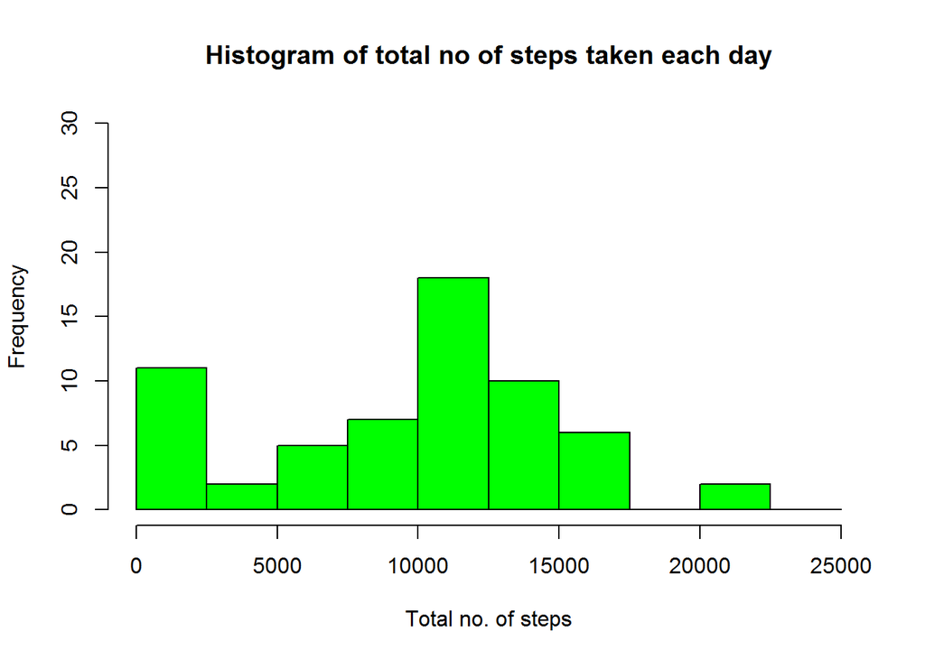

```r
  hist(sum_data$totalsteps, col="green",breaks = seq(from=0 , to= 25000 , by=2500 ),ylim=c(0,30),xlab= "Total no. of steps" , main = "Histogram of total no of steps taken each day")
```

**Calculate the mean and median of total steps taken**

```r
        mean(sum_data$totalsteps)
```

```
## [1] 9354.23
```

```r
        median(sum_data$totalsteps)
```

```
## [1] 10395
```

```r
        summary(sum_data)
```

```
##       date              totalsteps
##  Min.   :2012-10-01   Min.   :    0
##  1st Qu.:2012-10-16   1st Qu.: 6778
##  Median :2012-10-31   Median :10395
##  Mean   :2012-10-31   Mean   : 9354
##  3rd Qu.:2012-11-15   3rd Qu.:12811
##  Max.   :2012-11-30   Max.   :21194
```

**Calculate the average or mean activity pattern**

```r
mean_data <- aggregate(activity_raw$steps , by=list(activity_raw$interval),FUN=mean , na.rm=TRUE)
names(mean_data)<- c("Interval","Mean.Steps")
```

**Plot a time series graph of average steps vs interval**

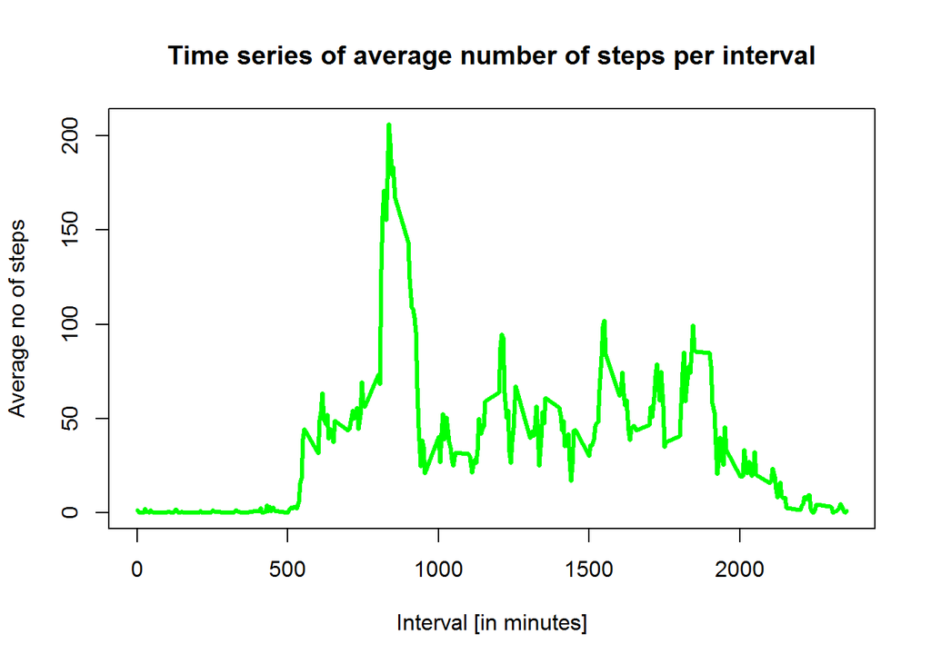

```r
plot(mean_data$Interval,mean_data$Mean.Steps,type="l",lwd=3,col="green",xlab="Interval [in minutes]" , ylab="Average no of steps",main="Time series of average number of steps per interval")
```

```r
max_steps <- which(mean_data$Mean.Steps== max(mean_data$Mean.Steps))
max_step_data <- mean_data[max_steps,1]
max_step_data
```

```
## [1] 835
```

**calculate and store the positions of missing values in the raw data set**

```r
NA_Count <- sum(is.na(activity_raw$steps))
NA_Count
```

```
## [1] 2304
```

```r
NA_Positions <- which(is.na(activity_raw$steps))
```

**Fill the missing values with the average steps**

```r
mean_vec <- rep(mean(activity_raw$steps ,na.rm = TRUE) , times= length(NA_Positions))
activity_raw[NA_Positions, "steps"] <- mean_vec
```

**Calculate the total steps taken each day with the NA values replaced by cacluated mean**

```r
sum_data_na_filled <- aggregate(activity_raw$steps,by=list(activity_raw$date),FUN=sum)
str(sum_data_na_filled)
```

```
## 'data.frame':    61 obs. of  2 variables:
##  $ Group.1: POSIXct, format: "2012-10-01" "2012-10-02" ...
##  $ x      : num  10766 126 11352 12116 13294 ...
```

```r
names(sum_data_na_filled) <- c("date", "total.steps")
str(sum_data_na_filled)
```

```
## 'data.frame':    61 obs. of  2 variables:
##  $ date       : POSIXct, format: "2012-10-01" "2012-10-02" ...
##  $ total.steps: num  10766 126 11352 12116 13294 ...
```

**Plot a histogram to display total steps taken each day, NA values now replaced with mean**

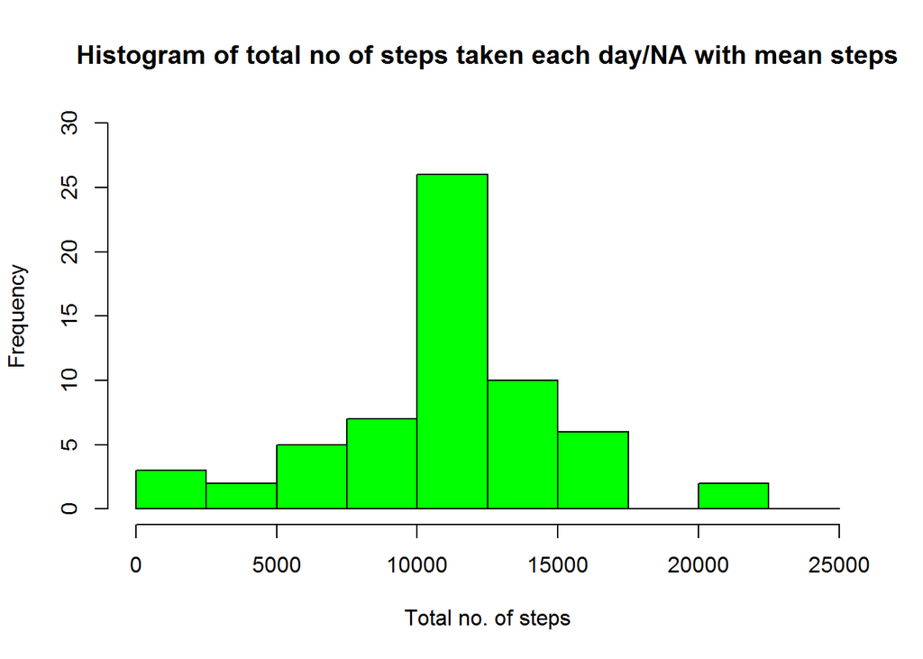

```r
hist(sum_data_na_filled$total.steps, col="green",breaks = seq(from=0 , to= 25000 , by=2500 ),ylim=c(0,30),xlab= "Total no. of steps" , main = "Histogram of total no of steps taken each day/NA with mean steps")
```

**Recalcualte the mean and median with NA’s replaced**

```r
mean(sum_data_na_filled$total.steps)
```

```
## [1] 10766.19
```

```r
median(sum_data_na_filled$total.steps)
```

```
## [1] 10766.19
```

**Calculate the average steps taken and categorise by weekday/weekend**

```r
mean_data_na_filled_daytype <- aggregate(activity_raw$steps,by=list(activity_raw$daytype,activity_raw$weekday,activity_raw$interval), FUN=mean)
names(mean_data_na_filled_daytype)<- c("DayType","Weekday","interval","mean.steps")
```

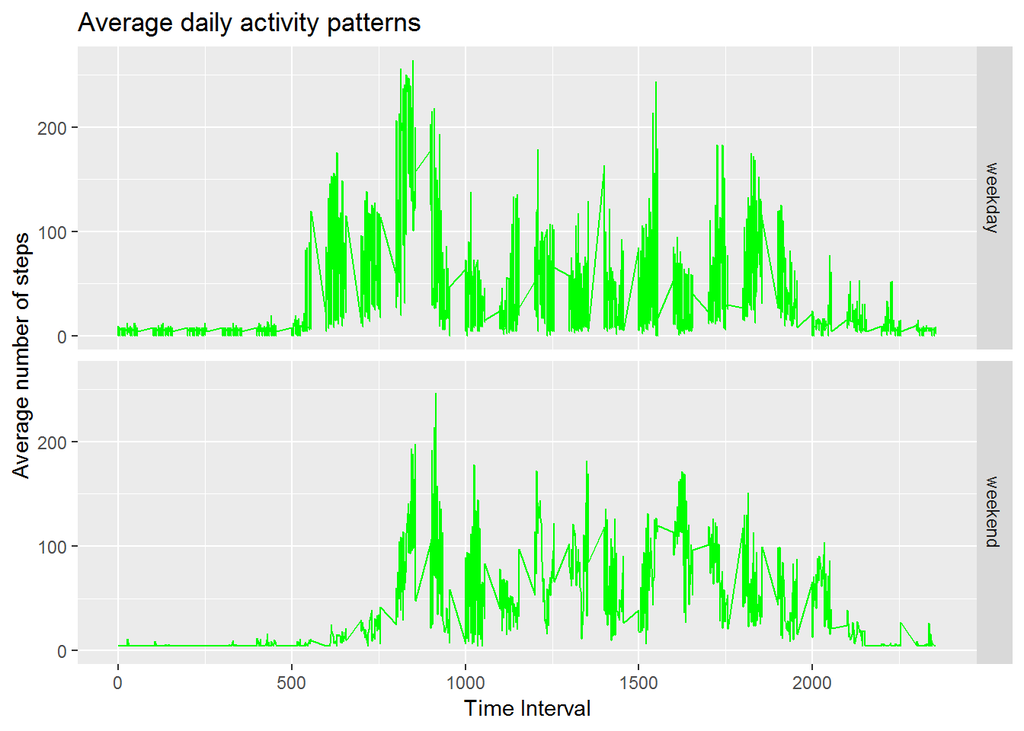

```r
library(ggplot2)
g<- ggplot(data=mean_data_na_filled_daytype,aes(x=interval, y=mean.steps))
g+geom_line(col="green")+facet_grid(mean_data_na_filled_daytype$DayType ~.)+ggtitle("Average daily activity patterns")+ xlab("Time Interval")+ylab("Average number of steps")+theme_grey()
```